# Caso Brand Equity

Data Analysis with R

Elaborado por *Dyjannette Alva Quiroz

## **1. Introducción**

El presente caso se analiza desde la perspectiva de la investigación de mercado realizada por Ariel Research. La investigación ha recopilado un gran conjunto de datos sobre el valor de la marca para los sectores de Comida Rápida y Viajes. El valor de marca se identifica como el valor agregado a una marca debido a su nombre. Un alto valor de marca ayuda a las empresas a mantener su ventaja competitiva.

Tipicamente el valor de la marca puede ser dividida en dos áreas: Valor de marca financiera y valor de marca de mercadeo.El valor de la marca financiera se puede describir como “el valor asignado a una marca en el balance, que representa el valor que se cree que reside en el nombre de la marca”. El valor de marca de marketing, que es el área de valor de marca explorado en el conjunto de datos de Ariel, puede describirse como “el valor agregado a una marca debido a su nombre respaldado por la lealtad del consumidor, la voluntad de comprar a un precio superior, la resistencia a los esfuerzos del marketing de la competencia, etc.”

El valor de marca es un concepto difícil de medir debido a su naturaleza intangible y compleja. Ariel Research intentó cuantificar el valor de la marca, es decir, convertir un concepto intangible en una medida tangible, creando una medida multidimensional con cinco dimensiones principales: familiaridad, popularidad, relevancia, lealtad y singularidad.

## **2. Objetivo del caso**

Determinar la forma de medir el valor de una marca.

Objetivos Específicos:

- Determinar el impacto de las variables: lealtad, relevancia, familiaridad, singularidad y popularidad; en el valor de la marca.
- Establecer las diferencias significativas según las categorías: edad, región, ingresos y género.

## **3. Análisis**

```
* 1. Fast food
```

```r
Base1 = read.xlsx("FAST FOOD-1.xlsx", sheetName = "Sheet1")
glimpse(Base1)
```

```
## Rows: 1,500
## Columns: 18
## $ gender       <dbl> 2, 1, 2, 1, 1, 1, 1, 1, 2, 1, 2, 1, 2, 2, 1, 1, 1, 1, 2, ~
## $ age          <dbl> 59, 60, NA, 49, 53, 48, 38, 62, 61, 44, 46, 44, 54, 48, 4~
## $ children     <dbl> 2, 2, 2, 2, 2, 1, 1, 2, 2, 2, 1, 2, 2, 2, 1, 1, 2, 2, 1, ~
## $ income       <dbl> 2, 3, 1, 3, 1, 2, 3, 3, 4, 1, 2, 3, 2, 2, 3, 4, 1, 2, 2, ~
## $ famil        <dbl> 5, 1, 5, 1, 10, 6, 9, 6, 1, 8, 8, 5, 5, 2, 5, 7, 9, 6, 8,~
## $ uniqu        <dbl> 6, 1, 5, 8, 9, 7, 2, 6, 3, 5, 3, 9, 5, 4, 1, 8, 7, 5, 8, ~
## $ relev        <dbl> 5, 1, 1, 4, 10, 8, 3, 6, 1, 3, 5, 4, 7, 3, 7, 7, 7, 6, 9,~
## $ loyal        <dbl> 6, 1, 5, 7, 9, 8, 2, 6, 2, 5, 5, 6, 7, 2, 5, 5, 7, 5, 8, ~
## $ popul        <dbl> 8, 1, 5, 7, 9, 7, 9, 6, 4, 8, 10, 7, 7, 6, 3, 7, 8, 5, 9,~
## $ category     <dbl> 12, 12, 12, 12, 12, 12, 12, 12, 12, 12, 12, 12, 12, 12, 1~
## $ brand        <dbl> 263, 263, 263, 263, 263, 263, 263, 263, 263, 263, 263, 26~
## $ familbin     <dbl> 0, 0, 0, 0, 1, 0, 1, 0, 0, 1, 1, 0, 0, 0, 0, 0, 1, 0, 1, ~
## $ uniqubin     <dbl> 0, 0, 0, 1, 1, 0, 0, 0, 0, 0, 0, 1, 0, 0, 0, 1, 0, 0, 1, ~
## $ relevbin     <dbl> 0, 0, 0, 0, 1, 1, 0, 0, 0, 0, 0, 0, 0, 0, 0, 0, 0, 0, 1, ~
## $ loyalbin     <dbl> 0, 0, 0, 0, 1, 1, 0, 0, 0, 0, 0, 0, 0, 0, 0, 0, 0, 0, 1, ~
## $ populbin     <dbl> 1, 0, 0, 0, 1, 0, 1, 0, 0, 1, 1, 0, 0, 0, 0, 0, 1, 0, 1, ~
## $ region       <dbl> 2, 3, 3, 3, 4, 2, 4, 3, 3, 1, 4, 4, 4, 4, 1, 3, 4, 1, 4, ~
## $ brand_equity <dbl> 5.33, 1.33, 3.67, 5.00, 8.00, 6.33, 4.67, 5.50, 2.50, 5.0~
```

```r
tibble(Base1)
```

```
## # A tibble: 1,500 x 18
##    gender   age children income famil uniqu relev loyal popul category brand
##     <dbl> <dbl>    <dbl>  <dbl> <dbl> <dbl> <dbl> <dbl> <dbl>    <dbl> <dbl>
##  1      2    59        2      2     5     6     5     6     8       12   263
##  2      1    60        2      3     1     1     1     1     1       12   263
##  3      2    NA        2      1     5     5     1     5     5       12   263
##  4      1    49        2      3     1     8     4     7     7       12   263
##  5      1    53        2      1    10     9    10     9     9       12   263
##  6      1    48        1      2     6     7     8     8     7       12   263
##  7      1    38        1      3     9     2     3     2     9       12   263
##  8      1    62        2      3     6     6     6     6     6       12   263
##  9      2    61        2      4     1     3     1     2     4       12   263
## 10      1    44        2      1     8     5     3     5     8       12   263
## # ... with 1,490 more rows, and 7 more variables: familbin <dbl>,
## #   uniqubin <dbl>, relevbin <dbl>, loyalbin <dbl>, populbin <dbl>,
## #   region <dbl>, brand_equity <dbl>
```

```r
df_status(Base1)
```

```
##        variable q_zeros p_zeros q_na p_na q_inf p_inf    type unique
## 1        gender       0    0.00    0 0.00     0     0 numeric      2
## 2           age       0    0.00   27 1.80     0     0 numeric     45
## 3      children       0    0.00    0 0.00     0     0 numeric      2
## 4        income       0    0.00    0 0.00     0     0 numeric      4
## 5         famil       0    0.00    1 0.07     0     0 numeric     10
## 6         uniqu       0    0.00    6 0.40     0     0 numeric     10
## 7         relev       0    0.00    6 0.40     0     0 numeric     10
## 8         loyal       0    0.00    0 0.00     0     0 numeric     10
## 9         popul       0    0.00    8 0.53     0     0 numeric     10
## 10     category       0    0.00    0 0.00     0     0 numeric      1
## 11        brand       0    0.00    0 0.00     0     0 numeric      5
## 12     familbin     622   41.47    1 0.07     0     0 numeric      2
## 13     uniqubin     879   58.60    6 0.40     0     0 numeric      2
## 14     relevbin     956   63.73    6 0.40     0     0 numeric      2
## 15     loyalbin     948   63.20    0 0.00     0     0 numeric      2
## 16     populbin     625   41.67    8 0.53     0     0 numeric      2
## 17       region       0    0.00    0 0.00     0     0 numeric      4
## 18 brand_equity       0    0.00    0 0.00     0     0 numeric     52
```

```
* 1. Actualizando los tipos de variables
```

```r
Base1$brand<-as.factor(Base1$brand)
levels(Base1$brand)<-c("A&W","Burger King","Harver's","Mc Donalds","Wendy's")
attach(Base1)

table(brand)
```

```
## brand
##         A&W Burger King    Harver's  Mc Donalds     Wendy's
##         283         291         316         308         302
```

```r
Base1$gender<-as.factor(Base1$gender)
levels(Base1$gender)<-c("Femenino","Masculino")
attach(Base1)
table(gender)
```

```
## gender
##  Femenino Masculino
##       889       611
```

```r
Base1$children<-as.factor(Base1$children)
levels(Base1$children)<-c("Si","No")
attach(Base1)
table(children)
```

```
## children
##  Si  No
## 739 761
```

```r
Base1$income<-as.factor(Base1$income)
levels(Base1$income)<-c("1. <$30k","2. [$30k-$50k>","3. [$50k-$75k>","4. >= $75k")
attach(Base1)
table(income)
```

```
## income
##       1. <$30k 2. [$30k-$50k> 3. [$50k-$75k>     4. >= $75k
##            333            400            451            316
```

```r
Base1$region<-as.factor(Base1$region)
levels(Base1$region)<-c("1. Maritimes","2. Quebec","3. Ontario","4. West")
attach(Base1)
table(region)
```

```
## region
## 1. Maritimes    2. Quebec   3. Ontario      4. West
##          119          350          554          477
```

```r
Base1$famil<-as.factor(Base1$famil)
Base1$uniqu<-as.factor(Base1$uniqu)
Base1$relev<-as.factor(Base1$relev)
Base1$loyal<-as.factor(Base1$loyal)
Base1$popul<-as.factor(Base1$popul)
Base1$popul<-as.factor(Base1$popul)

Base1$familbin<-as.factor(Base1$familbin)
levels(Base1$familbin)<-c("No Leal","Leal")

Base1$uniqubin<-as.factor(Base1$uniqubin)
levels(Base1$uniqubin)<-c("No Leal","Leal")

Base1$relevbin<-as.factor(Base1$relevbin)
levels(Base1$relevbin)<-c("No Leal","Leal")

Base1$loyalbin<-as.factor(Base1$loyalbin)
levels(Base1$loyalbin)<-c("No Leal","Leal")

Base1$populbin<-as.factor(Base1$populbin)
levels(Base1$populbin)<-c("No Leal","Leal")

df_status(Base1)
```

```
##        variable q_zeros p_zeros q_na p_na q_inf p_inf    type unique
## 1        gender       0       0    0 0.00     0     0  factor      2
## 2           age       0       0   27 1.80     0     0 numeric     45
## 3      children       0       0    0 0.00     0     0  factor      2
## 4        income       0       0    0 0.00     0     0  factor      4
## 5         famil       0       0    1 0.07     0     0  factor     10
## 6         uniqu       0       0    6 0.40     0     0  factor     10
## 7         relev       0       0    6 0.40     0     0  factor     10
## 8         loyal       0       0    0 0.00     0     0  factor     10
## 9         popul       0       0    8 0.53     0     0  factor     10
## 10     category       0       0    0 0.00     0     0 numeric      1
## 11        brand       0       0    0 0.00     0     0  factor      5
## 12     familbin       0       0    1 0.07     0     0  factor      2
## 13     uniqubin       0       0    6 0.40     0     0  factor      2
## 14     relevbin       0       0    6 0.40     0     0  factor      2
## 15     loyalbin       0       0    0 0.00     0     0  factor      2
## 16     populbin       0       0    8 0.53     0     0  factor      2
## 17       region       0       0    0 0.00     0     0  factor      4
## 18 brand_equity       0       0    0 0.00     0     0 numeric     52
```

```r
summary(Base1)
```

```
##        gender         age        children            income        famil
##  Femenino :889   Min.   :20.00   Si:739   1. <$30k      :333   10     :458
##  Masculino:611   1st Qu.:32.00   No:761   2. [$30k-$50k>:400   8      :222
##                  Median :39.00            3. [$50k-$75k>:451   9      :197
##                  Mean   :40.64            4. >= $75k    :316   5      :126
##                  3rd Qu.:48.00                                 1      :125
##                  Max.   :64.00                                 (Other):371
##                  NA's   :27                                    NA's   :  1
##      uniqu         relev         loyal         popul        category
##  8      :246   5      :213   8      :228   10     :424   Min.   :12
##  5      :239   10     :205   5      :222   8      :240   1st Qu.:12
##  10     :224   8      :201   1      :214   9      :203   Median :12
##  7      :156   1      :179   10     :213   7      :150   Mean   :12
##  9      :145   7      :147   7      :139   5      :144   3rd Qu.:12
##  (Other):484   (Other):549   6      :115   (Other):331   Max.   :12
##  NA's   :  6   NA's   :  6   (Other):369   NA's   :  8
##          brand        familbin      uniqubin      relevbin      loyalbin
##  A&W        :283   No Leal:622   No Leal:879   No Leal:956   No Leal:948
##  Burger King:291   Leal   :877   Leal   :615   Leal   :538   Leal   :552
##  Harver's   :316   NA's   :  1   NA's   :  6   NA's   :  6
##  Mc Donalds :308
##  Wendy's    :302
##
##
##     populbin            region     brand_equity
##  No Leal:625   1. Maritimes:119   Min.   :1.000
##  Leal   :867   2. Quebec   :350   1st Qu.:4.500
##  NA's   :  8   3. Ontario  :554   Median :6.170
##                4. West     :477   Mean   :5.819
##                                   3rd Qu.:7.330
##                                   Max.   :9.000
##
```

## **3.1 Análisis de Correspondencias**

#Visualizando la tabla de contingencia

1. Convertir la base como una tabla

```r
dtGrupo1<-table(Base1$famil, Base1$brand) #aquí empezamos
dtGrupo1
```

```
##
##      A&W Burger King Harver's Mc Donalds Wendy's
##   1   15          16       50          3      41
##   2   15          11       22          4      13
##   3   13          12       13          2      12
##   4   12          10       11          1      15
##   5   34          32       26         10      24
##   6   24          15       18         10      25
##   7   15          31       24         17      26
##   8   52          47       36         43      44
##   9   21          41       37         67      31
##   10  82          76       79        150      71
```

2. Gráfico

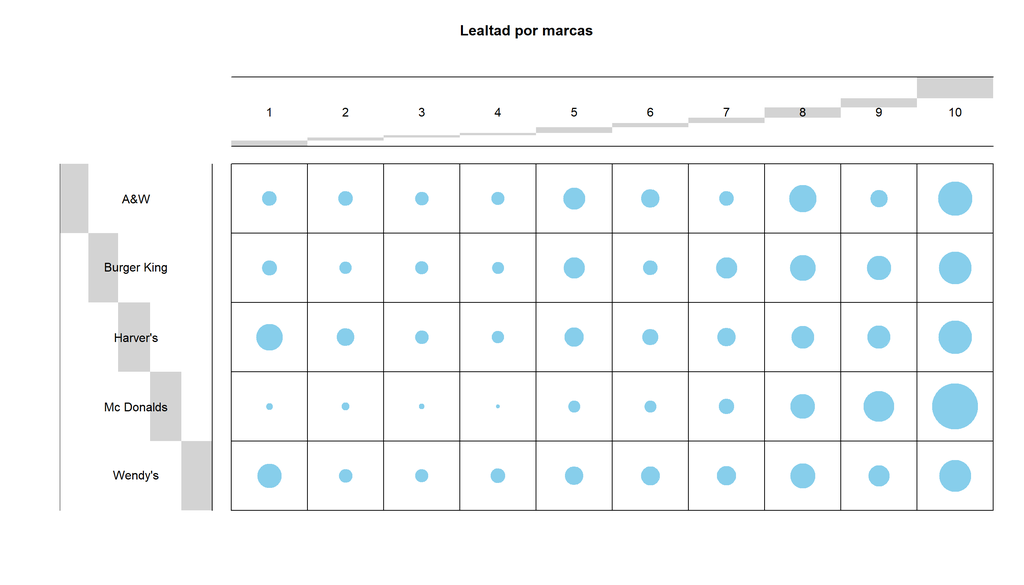

```r
balloonplot(dtGrupo1, main ="Lealtad por marcas", xlab ="", ylab="",
            label = FALSE, show.margins = FALSE)
```

***

### **2. Tabla de Perfiles**

- Creando los perfiles fila

```r
dtGrupo1.row = dtGrupo1/rowSums(dtGrupo1)

mass.row = colMeans(dtGrupo1.row)


Perfil_fila=rbind(dtGrupo1.row,mass.row)
Perfil_fila
```

```
##                A&W Burger King  Harver's Mc Donalds   Wendy's
## 1        0.1200000   0.1280000 0.4000000 0.02400000 0.3280000
## 2        0.2307692   0.1692308 0.3384615 0.06153846 0.2000000
## 3        0.2500000   0.2307692 0.2500000 0.03846154 0.2307692
## 4        0.2448980   0.2040816 0.2244898 0.02040816 0.3061224
## 5        0.2698413   0.2539683 0.2063492 0.07936508 0.1904762
## 6        0.2608696   0.1630435 0.1956522 0.10869565 0.2717391
## 7        0.1327434   0.2743363 0.2123894 0.15044248 0.2300885
## 8        0.2342342   0.2117117 0.1621622 0.19369369 0.1981982
## 9        0.1065990   0.2081218 0.1878173 0.34010152 0.1573604
## 10       0.1790393   0.1659389 0.1724891 0.32751092 0.1550218
## mass.row 0.2028994   0.2009202 0.2349811 0.13442175 0.2267776
```

El perfil de fila muestra que el valor de masa más grande es 0.2349 que se encuentra en la marca Harver’s.

Este gráfico muestra las probabilidades de ocurrencia en cada celda de acuerdo a las categorias.

- Creando los perfiles columna

```r
dtGrupo1.col = t(dtGrupo1)/colSums(dtGrupo1)

mass.col = rowMeans(t(dtGrupo1.col))


Perfil_col=rbind(dtGrupo1.col,mass.col)
Perfil_col
```

```
##                       1          2           3           4          5
## A&W         0.053003534 0.05300353 0.045936396 0.042402827 0.12014134
## Burger King 0.054982818 0.03780069 0.041237113 0.034364261 0.10996564
## Harver's    0.158227848 0.06962025 0.041139241 0.034810127 0.08227848
## Mc Donalds  0.009771987 0.01302932 0.006514658 0.003257329 0.03257329
## Wendy's     0.135761589 0.04304636 0.039735099 0.049668874 0.07947020
## mass.col    0.082349555 0.04330003 0.034912501 0.032900684 0.08488579
##                      6          7         8          9        10
## A&W         0.08480565 0.05300353 0.1837456 0.07420495 0.2897527
## Burger King 0.05154639 0.10652921 0.1615120 0.14089347 0.2611684
## Harver's    0.05696203 0.07594937 0.1139241 0.11708861 0.2500000
## Mc Donalds  0.03257329 0.05537459 0.1400651 0.21824104 0.4885993
## Wendy's     0.08278146 0.08609272 0.1456954 0.10264901 0.2350993
## mass.col    0.06173376 0.07538988 0.1489884 0.13061541 0.3049239
```

### **3. Prueba de Independencia**

Para interpretar el análisis de correspondencia, el primer paso es evaluar si existe una dependencia significativa entre las filas y las columnas.

Hipótesis

H0: Asume que no existe asociación entre la marca y la FAMILIARIDAD H1: Asume que existe asociación entre la marca y la FAMILIARIDAD

```r
chisq = chisq.test(dtGrupo1)
chisq
```

```
##
##  Pearson's Chi-squared test
##
## data:  dtGrupo1
## X-squared = 200.34, df = 36, p-value < 2.2e-16
```

Debido a que el valor de p-value < 2.2e-16 es menor que el 0.05 (α), la decisión es rechazar la hipótesis nula. Entonces, con base en la prueba de Chi-Cuadrado, se puede concluir que existe asociación entre la marca y la FAMILIARIDAD con el nivel de significancia del 0.05.

### **4. Análisis de correspondencia**

El análisis de correspondencia es un análisis multivariado que utiliza el concepto de análisis de componentes principales. Para buscar la varianza, es necesario calcular el valor propio.

```
* Análisis de correspondencia
```

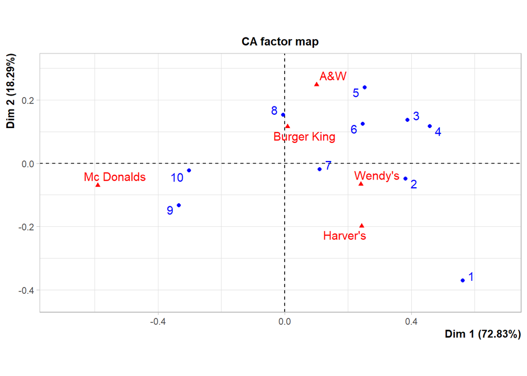

```r
res.ca = CA(dtGrupo1, graph = TRUE)
```

```r
print(res.ca)
```

```
## **Results of the Correspondence Analysis (CA)**
## The row variable has  10  categories; the column variable has 5 categories
## The chi square of independence between the two variables is equal to 200.3443 (p-value =  1.089295e-24 ).
## *The results are available in the following objects:
##
##    name              description
## 1  "$eig"            "eigenvalues"
## 2  "$col"            "results for the columns"
## 3  "$col$coord"      "coord. for the columns"
## 4  "$col$cos2"       "cos2 for the columns"
## 5  "$col$contrib"    "contributions of the columns"
## 6  "$row"            "results for the rows"
## 7  "$row$coord"      "coord. for the rows"
## 8  "$row$cos2"       "cos2 for the rows"
## 9  "$row$contrib"    "contributions of the rows"
## 10 "$call"           "summary called parameters"
## 11 "$call$marge.col" "weights of the columns"
## 12 "$call$marge.row" "weights of the rows"
```

```
* Autovalores
```

```r
#library(factoextra)
eig.val = get_eigenvalue(res.ca)
eig.val
```

```
##        eigenvalue variance.percent cumulative.variance.percent
## Dim.1 0.097343640        72.833664                    72.83366
## Dim.2 0.024449027        18.293052                    91.12672
## Dim.3 0.008195577         6.132028                    97.25874
## Dim.4 0.003663744         2.741256                   100.00000
```

```
* Gráfico de sedimentación
```

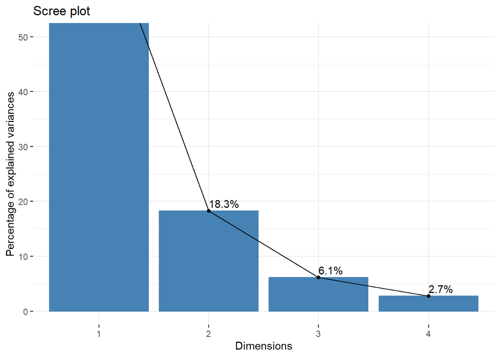

```
* Representación
```

```r
fviz_screeplot(res.ca, addlabels = TRUE, ylim = c(0, 50))
```

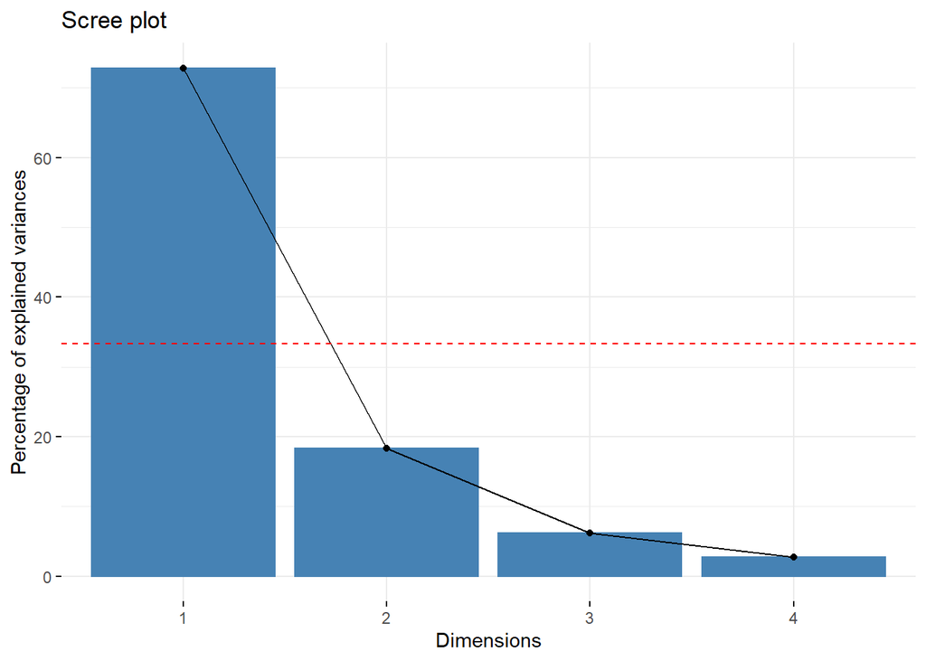

```r
fviz_screeplot(res.ca) +
 geom_hline(yintercept=33.33, linetype=2, color="red")
```

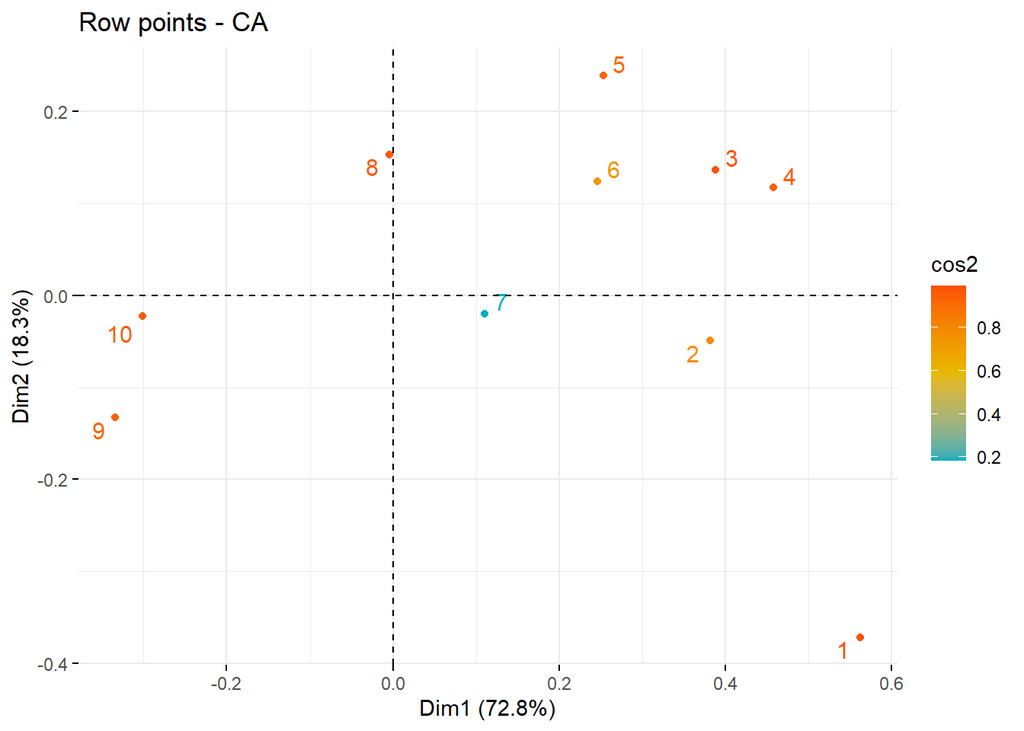

```r
fviz_ca_row(res.ca, col.row = "cos2",
             gradient.cols = c("#00AFBB", "#E7B800", "#FC4E07"),
             repel = TRUE)
```

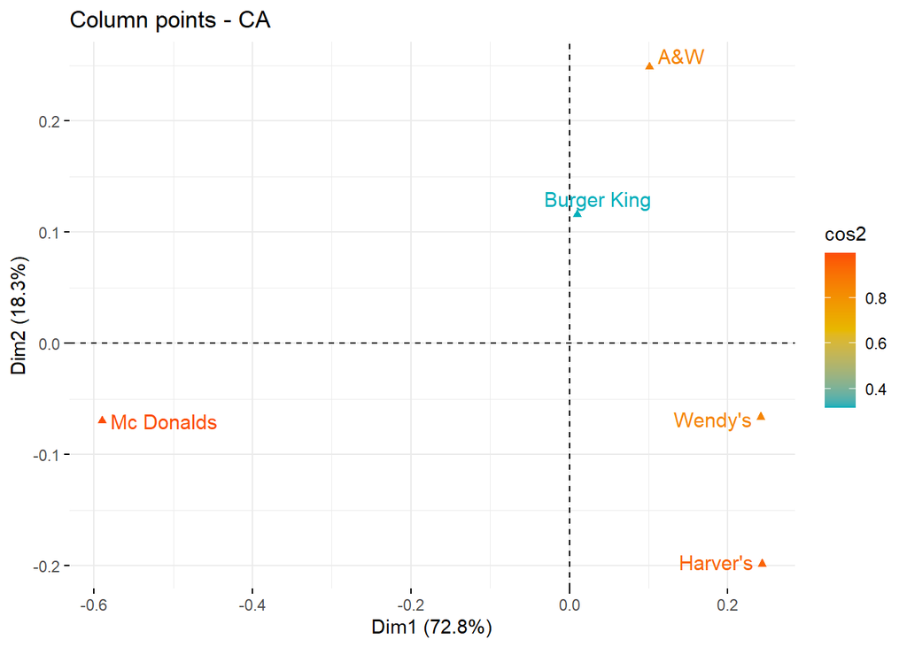

```r
fviz_ca_col(res.ca, col.col = "cos2",
             gradient.cols = c("#00AFBB", "#E7B800", "#FC4E07"),
             repel = TRUE)
```

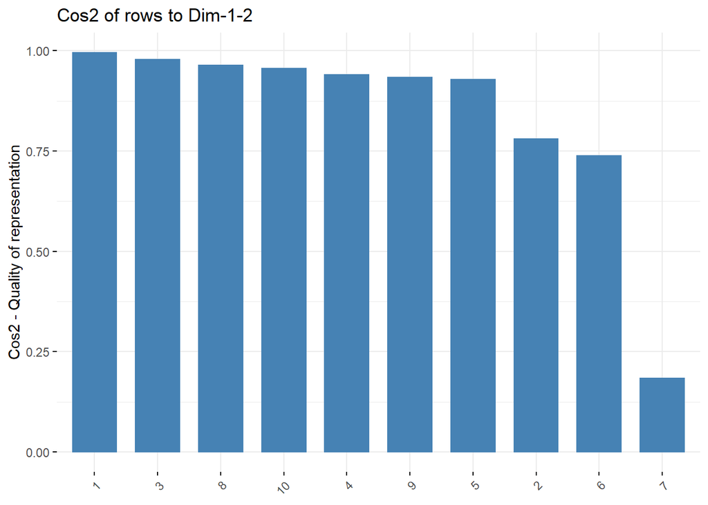

```r
# Cos2 de filas en Dim.1 y Dim.2
fviz_cos2(res.ca, choice = "row", axes = 1:2)
```

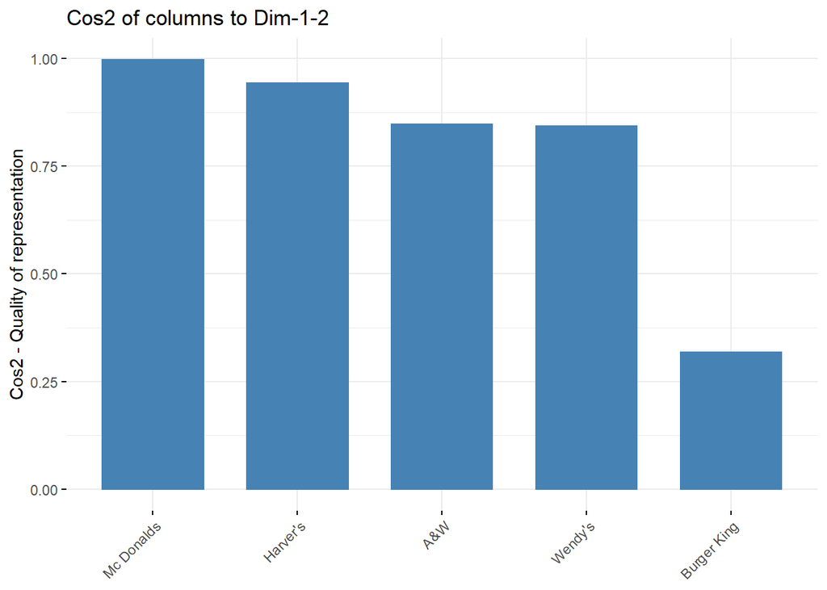

```r
# Cos2 de columnas en Dim.1 y Dim.2

fviz_cos2(res.ca, choice = "col", axes = 1:2)
```

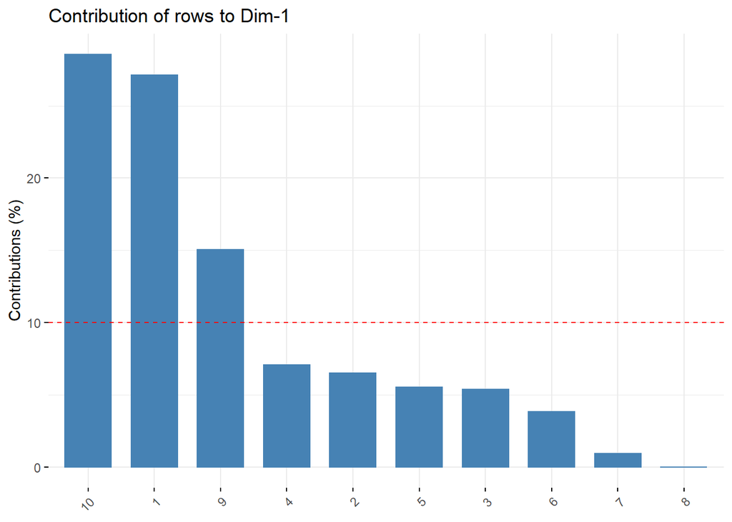

```r
# Contribuciones de filas en la Dim.1
fviz_contrib(res.ca, choice = "row", axes = 1, top = 10)
```

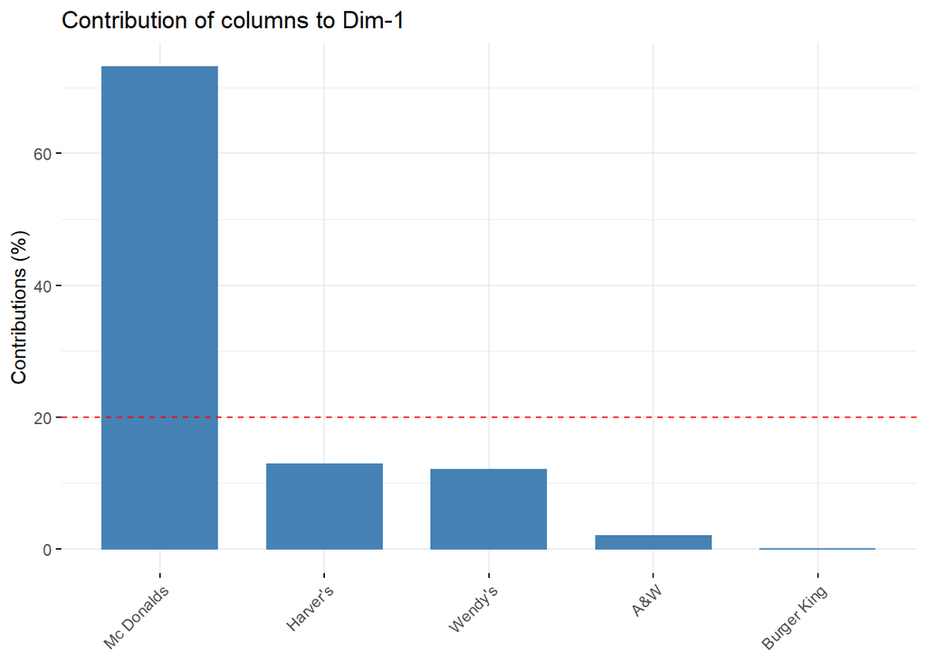

```r
# Contribuciones de columnas en la Dim.1
fviz_contrib(res.ca, choice = "col", axes = 1, top = 10)
```

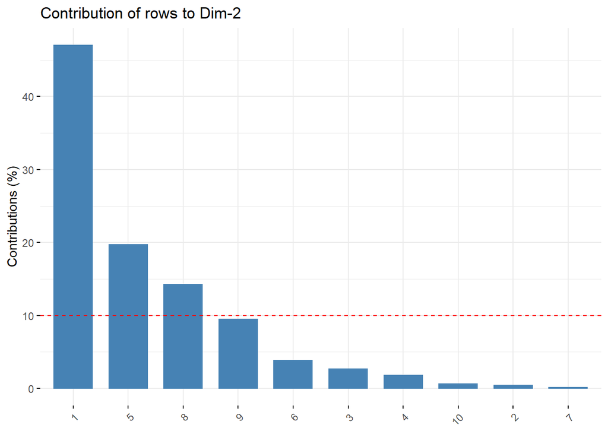

```r
# Contribuciones de filas en la Dim.2
fviz_contrib(res.ca, choice = "row", axes = 2, top = 10)
```

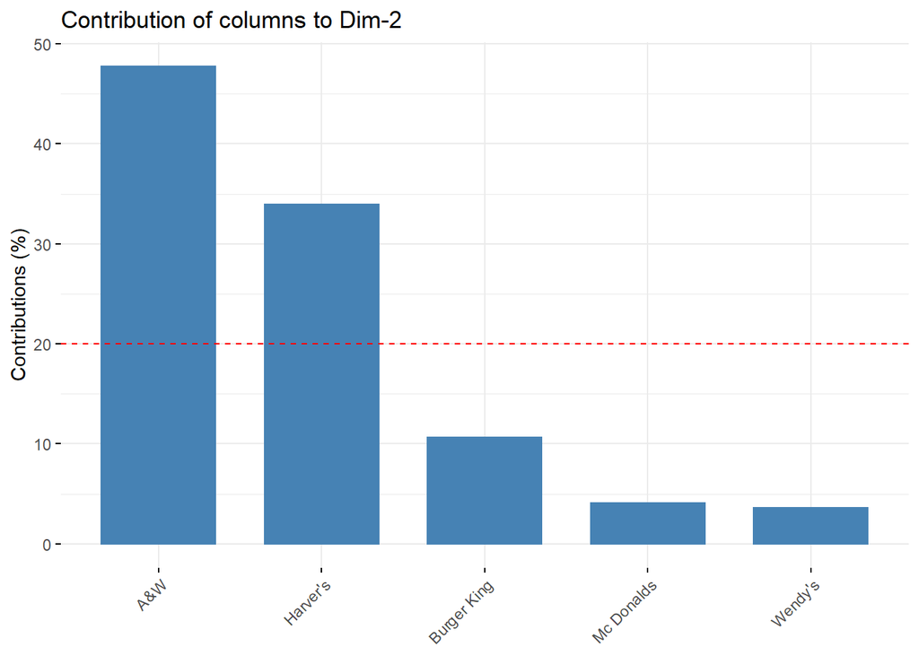

```r
# Contribuciones de columnas en la Dim.2
fviz_contrib(res.ca, choice = "col", axes = 2, top = 10)
```

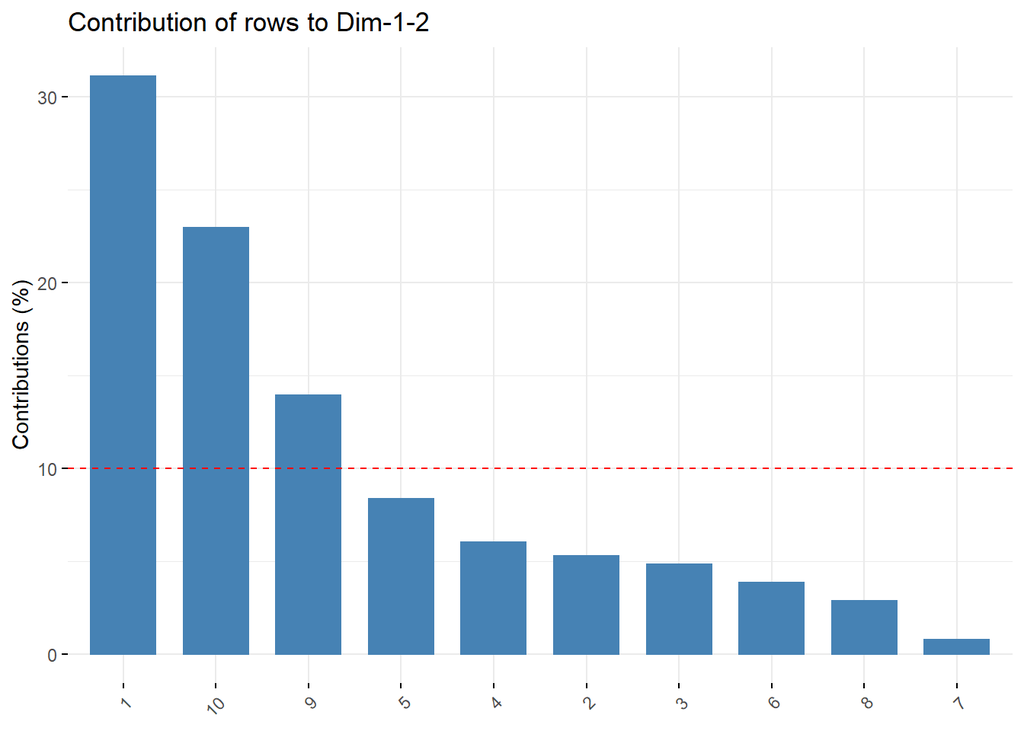

```r
# Contribución total en Dim.1 y Dim.2
fviz_contrib(res.ca, choice = "row", axes = 1:2, top = 10)
```

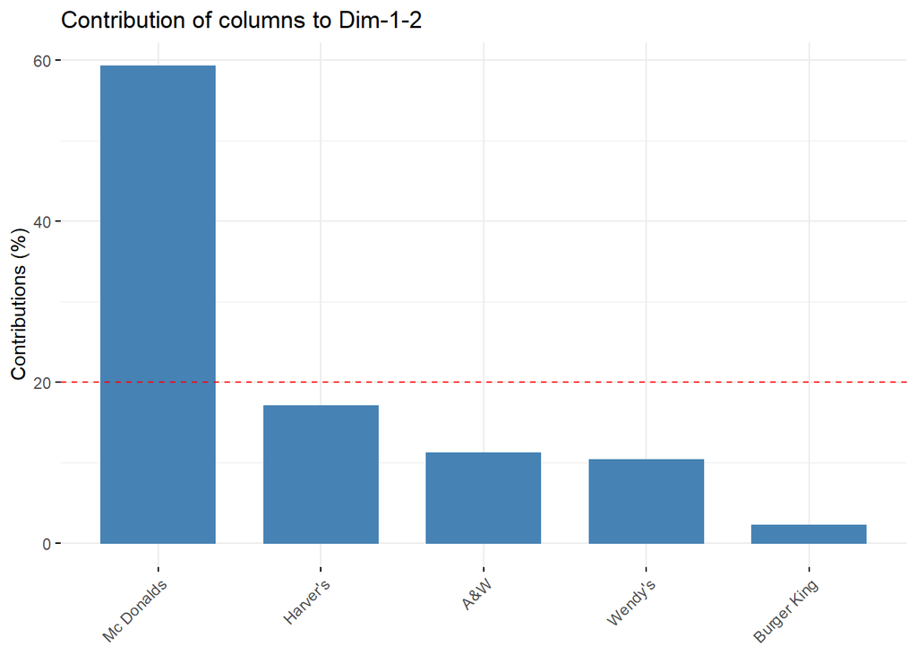

```
* Test de Malinvaud
```

```r
# Contribución total en Dim.1 y Dim.2
fviz_contrib(res.ca, choice = "col", axes = 1:2, top = 10)
```

```r
malinvaud(dtGrupo1)
```

```
##      K Dimension Eigen value Chi-square df  p value
## [1,] 0         1 0.097343640 200.344331 36 0.000000
## [2,] 1         2 0.024449027  54.426214 24 0.000374
## [3,] 2         3 0.008195577  17.777122 14 0.217121
## [4,] 3         4 0.003663744   5.491952  6 0.482430
```

[figure not shown]

```
* Test basados en permutación
```

```r
sig.tot.inertia.perm(dtGrupo1)
```

```
## [1] "It is estimated that your iterations will take 0.33 minutes."
## [1] "R is not in interactive() mode. Resample-based tests will be conducted. Please take note of the progress bar."
## ================================================================================
```

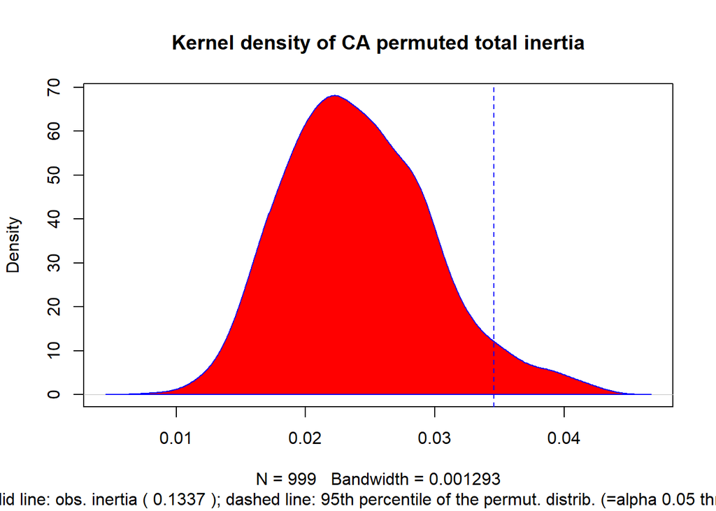

```
## [1] "observed total inertia: 0.1337"
## [1] "95th percentile of the permuted total inertia: 0.03457"
## [1] "if the observed inertia is larger than the 95th percentile, the observed inertia is significant at alpha 0.05"
```

Este gráfico, devuelve la curva de frecuencia de la inercia total permutada (basada en 999 tablas simuladas). La inercia total observada (0,1337) y otra el percentil 95 (0.03457). Permiten evaluar visualmente la importancia de la inercia total observada. En este caso, la prueba arroja un resultado significativo, lo que indica que la hipótesis de independencia entre marca y FAMILIARIDAD puede rechazarse. Este comando se puede utilizar en lugar de la prueba tradicional de chi-cuadrado.

```r
sig.dim.perm(dtGrupo1,1,2)
```

```
## [1] "It is estimated that your iterations will take 0.33 minutes."
## [1] "R is not in interactive() mode. Resample-based tests will be conducted. Please take note of the progress bar."
## ================================================================================
```

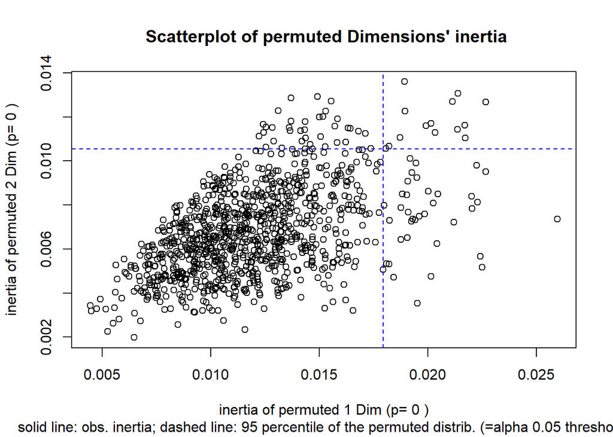

```
## [1] "p value of dim 1 = 0"
## [1] "p value of dim 2 = 0"
```

Se implementa una prueba basada en permutación (que se usa en 999 tablas simuladas) para probar la importancia de cualquier par de dimensiones. Se devuelve el diagrama de dispersión, donde las inercias permutadas de dimensión 1 y 2 se grafican entre sí. Nuevamente, las líneas de referencia que representan la inercia de las dimensiones observadas y permutadas permiten evaluar visualmente la importancia. Este último también se indica en las etiquetas de los ejes. En el gráfico, ambas dimensiones son significativas con un alfa de 0.05, y las dimensiones 1 y 2 tienen un valor p=0.

```r
#Imputando valores
frecuencias <- data.frame(table(Base1$famil))
moda <- frecuencias[which.max(frecuencias$Freq),1]

Base1$famil<-replace(Base1$famil,is.na(Base1$famil),moda)

frecuencias <- data.frame(table(Base1$uniqu))
moda <- frecuencias[which.max(frecuencias$Freq),1]

Base1$uniqu<-replace(Base1$uniqu,is.na(Base1$uniqu),moda)

frecuencias <- data.frame(table(Base1$relev))
moda <- frecuencias[which.max(frecuencias$Freq),1]

Base1$relev<-replace(Base1$relev,is.na(Base1$relev),moda)

frecuencias <- data.frame(table(Base1$loyal))
moda <- frecuencias[which.max(frecuencias$Freq),1]


Base1$loyal<-replace(Base1$loyal,is.na(Base1$loyal),moda)

frecuencias <- data.frame(table(Base1$popul))
moda <- frecuencias[which.max(frecuencias$Freq),1]

Base1$popul<-replace(Base1$popul,is.na(Base1$popul),moda)

# seleccionando columnas

newBase1 = Base1[, c("famil", "uniqu", "relev", "loyal","popul","brand")]


# Número de categorias por variable


cats = apply(newBase1, 2, function(x) nlevels(as.factor(x)))
cats
```

```
## famil uniqu relev loyal popul brand
##    10    10    10    10    10     5
```

```r
# Aplicando MCA

mca1 = MCA(newBase1, graph = FALSE)

# Tabla de autovalores
mca1$eig
```

```
##        eigenvalue percentage of variance cumulative percentage of variance
## dim 1  0.61473029              7.5273096                           7.52731
## dim 2  0.51293477              6.2808339                          13.80814
## dim 3  0.41257470              5.0519350                          18.86008
## dim 4  0.35035319              4.2900391                          23.15012
## dim 5  0.29664556              3.6323947                          26.78251
## dim 6  0.27396962              3.3547300                          30.13724
## dim 7  0.25265881              3.0937813                          33.23102
## dim 8  0.23939905              2.9314169                          36.16244
## dim 9  0.21579116              2.6423408                          38.80478
## dim 10 0.19641101              2.4050327                          41.20981
## dim 11 0.18629383              2.2811489                          43.49096
## dim 12 0.18374038              2.2498822                          45.74085
## dim 13 0.17847898              2.1854569                          47.92630
## dim 14 0.17816486              2.1816106                          50.10791
## dim 15 0.17243593              2.1114604                          52.21937
## dim 16 0.17198366              2.1059224                          54.32530
## dim 17 0.16762222              2.0525170                          56.37781
## dim 18 0.16482252              2.0182349                          58.39605
## dim 19 0.16077673              1.9686946                          60.36474
## dim 20 0.15662023              1.9177987                          62.28254
## dim 21 0.15218773              1.8635232                          64.14606
## dim 22 0.14724182              1.8029610                          65.94902
## dim 23 0.14556904              1.7824780                          67.73150
## dim 24 0.14168501              1.7349185                          69.46642
## dim 25 0.14082271              1.7243598                          71.19078
## dim 26 0.13986971              1.7126903                          72.90347
## dim 27 0.13821053              1.6923738                          74.59585
## dim 28 0.13591855              1.6643087                          76.26015
## dim 29 0.13156279              1.6109729                          77.87113
## dim 30 0.13060670              1.5992657                          79.47039
## dim 31 0.12670861              1.5515341                          81.02193
## dim 32 0.12351761              1.5124605                          82.53439
## dim 33 0.12162139              1.4892415                          84.02363
## dim 34 0.11928590              1.4606437                          85.48427
## dim 35 0.11317228              1.3857830                          86.87006
## dim 36 0.10658281              1.3050956                          88.17515
## dim 37 0.10652987              1.3044474                          89.47960
## dim 38 0.10039736              1.2293555                          90.70895
## dim 39 0.09410090              1.1522560                          91.86121
## dim 40 0.08987083              1.1004592                          92.96167
## dim 41 0.08887481              1.0882629                          94.04993
## dim 42 0.08213323              1.0057130                          95.05565
## dim 43 0.07979539              0.9770864                          96.03273
## dim 44 0.06885930              0.8431751                          96.87591
## dim 45 0.06565789              0.8039742                          97.67988
## dim 46 0.05799398              0.7101304                          98.39001
## dim 47 0.05276882              0.6461488                          99.03616
## dim 48 0.04438706              0.5435150                          99.57967
## dim 49 0.03432654              0.4203250                         100.00000
```

```r
# Coordenadas por columna
head(mca1$var$coord)
```

```
##              Dim 1      Dim 2      Dim 3      Dim 4      Dim 5
## famil_1 2.13108532 -1.2830560 -0.8267574 -0.1908252  0.1877242
## famil_2 1.21517092  0.3992478  1.2791905  1.6012103 -2.1115478
## famil_3 0.93760961  0.8787731  1.5008945  0.5494756  0.7498429
## famil_4 0.94367046  0.8713176  1.3684280  0.1045498  2.3081486
## famil_5 0.50961741  0.6159886  0.1959543 -0.8747402 -0.1230347
## famil_6 0.02546422  0.9291805 -0.1475527 -1.0500497 -0.2050854
```

```r
# Coordenadas por fila
head(mca1$ind$coord)
```

```
##         Dim 1      Dim 2      Dim 3      Dim 4      Dim 5
## 1  0.02611607  0.8731971 -0.1523791 -1.0154503 -0.3086590
## 2  2.13557946 -1.4870218 -0.9600950 -0.2945007  0.1413830
## 3  0.64747925  0.3735275  0.2090457 -0.8288307 -0.2227024
## 4  0.39337010  0.3289165 -0.3885982 -0.2136761  0.2692073
## 5 -0.75481438 -0.4517475 -0.1480518  0.6599069  0.3465679
## 6 -0.30538338  0.6173241 -0.5730747 -0.3105037 -0.3679152
```

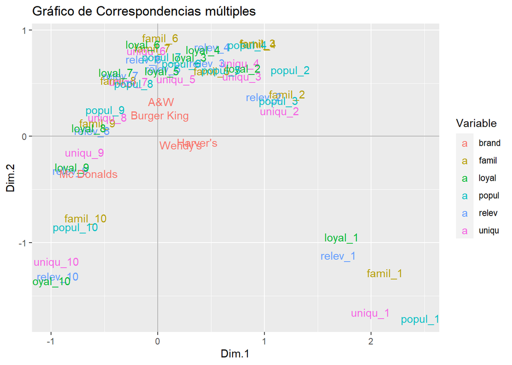

```r
# data frames para ggplot
mca1_vars_df = data.frame(mca1$var$coord, Variable = rep(names(cats), cats))
mca1_obs_df = data.frame(mca1$ind$coord)

# Gráficos para las categorias de las variables
ggplot(data = mca1_vars_df, aes(x = Dim.1, y = Dim.2, label = rownames(mca1_vars_df))) +
  geom_hline(yintercept = 0, colour = "gray70") +
  geom_vline(xintercept = 0, colour = "gray70") +
  geom_text(aes(colour = Variable)) + ggtitle("Gráfico de Correspondencias múltiples")
```

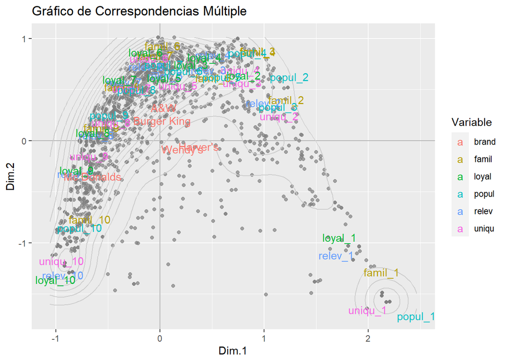

```r
# Gráfico MCA de observaciones y categorías

ggplot(data = mca1_obs_df, aes(x = Dim.1, y = Dim.2)) +
  geom_hline(yintercept = 0, colour = "gray70") +
  geom_vline(xintercept = 0, colour = "gray70") +
  geom_point(colour = "gray50", alpha = 0.7) +
  geom_density2d(colour = "gray80") +
  geom_text(data = mca1_vars_df, aes(x = Dim.1, y = Dim.2, label = rownames(mca1_vars_df), colour = Variable)) +
  ggtitle("Gráfico de Correspondencias Múltiple") +
  scale_colour_discrete(name = "Variable")
```

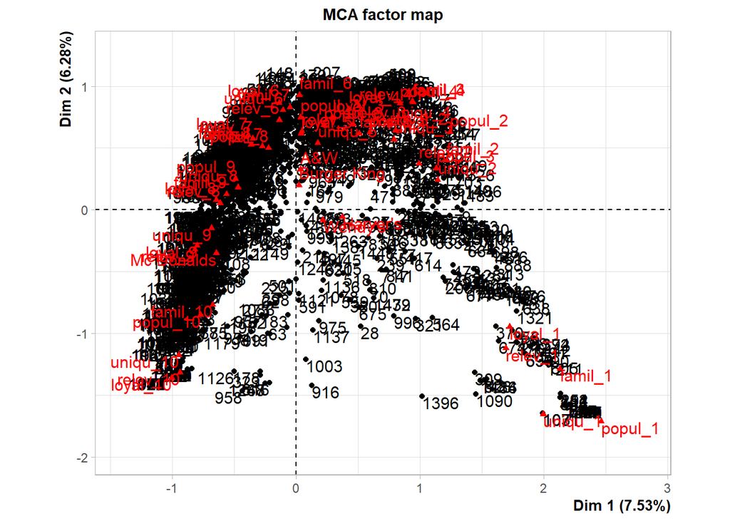

```r
# Biplot
plot(mca1)
```